# Sprint 8 : Tasca M8 T01

### Exercici 1

#### Descarrega el dataset adjunt, de registres de publicacions a Facebook sobre Tailàndia, i classifica els diferents registres utilitzant l'algorisme de K-means

```python
# Tratamiento de datos
# ==============================================================================
import pandas as pd
import numpy as np

# Gráficos
# ==============================================================================
import matplotlib.pyplot as plt
from matplotlib import style
import matplotlib.ticker as ticker
import seaborn as sns
from pprint import pprint

# Preprocesado y análisis
# ==============================================================================
#import statsmodels.api as sm
#import pingouin as pg
from scipy import stats
import random as rd
from imblearn.over_sampling import SMOTE

# Preprocesado y modelado
# ==============================================================================
from sklearn import neighbors, datasets, preprocessing
from sklearn.model_selection import train_test_split
from sklearn.metrics import accuracy_score
from sklearn.preprocessing import LabelEncoder
from sklearn.preprocessing import RobustScaler
from sklearn.decomposition import PCA
from sklearn.cluster import KMeans
from kneed import KneeLocator


# Test Estadísticos
# ==============================================================================
from scipy.stats import shapiro
from scipy.stats import ttest_ind
from scipy.stats import ttest_rel

# Ajuste de distribuciones
# ==============================================================================
from scipy import stats
import inspect
from statsmodels.distributions.empirical_distribution import ECDF
import scipy.cluster.hierarchy as shc



# Configuración matplotlib
# ==============================================================================
plt.style.use('ggplot')
from statsmodels.graphics.gofplots import qqplot
from matplotlib import pyplot

# Configuración warnings
# ==============================================================================
import warnings
warnings.filterwarnings('ignore')
```

### 1.1 Introducción

The 'Facebook Live Sellers in Thailand' is a dataset curated in UCI Machine Learning Datasets. The data contains 7050 observations and twelve attributes. The data is about live selling feature on the Facebook platform. Each record consists of information about the time live information of sale is posted to Facebook and engagements in the data. The engagements are regular Facebook interactions such as share and emotion rection. Details and academic publications relating to the data is available from the source https://archive.ics.uci.edu/ml/datasets/Facebook+Live+Sellers+in+Thailand.

Facebook Live Sellers in Thailand Data Set

Abstract: Facebook pages of 10 Thai fashion and cosmetics retail sellers. Posts of a different nature (video, photos, statuses, and links). Engagement metrics consist of comments, shares, and reactions.

- Data Set Characteristics: Multivariate
- Number of Instances: 7051
- Area: Business
- Attribute Characteristics: Integer
- Number of Attributes:12
- Date Donated: 2019-04-22
- Associated Tasks: Clustering
- Missing Values?: N/A
- Number of Web Hits: 65141

Source: Nassim Dehouche, Mahidol University International College, nassim.deh '@' mahidol.edu

Data Set Information:

- The variability of consumer engagement is analysed through a Principal Component Analysis, highlighting the changes induced by the use of Facebook Live. The seasonal component is analysed through a study of the averages of the different engagement metrics for different time-frames (hourly, daily and monthly). Finally, we identify statistical outlier posts, that are qualitatively analyzed further, in terms of their selling approach and activities.

Attribute Information:

- status_id
- status_type
- status_published
- num_reactions
- num_comments
- num_shares
- num_likes
- num_loves
- num_wows
- num_hahas
- num_sads
- num_angrys

Relevant Papers:

- Nassim Dehouche and Apiradee Wongkitrungrueng. Facebook Live as a Direct Selling Channel, 2018, Proceedings of ANZMAC 2018: The 20th Conference of the Australian and New Zealand Marketing Academy. Adelaide (Australia), 3-5 December 2018. Dehouche, N., 2020, Dataset on usage and engagement patterns for Facebook Live sellers in Thailand. Data in Brief, 30(105661).
- Wongkitrungrueng, A., Dehouche, N., and Assarut, N., 2020, Live streaming commerce from the seller's perspective: implications for online relationship marketing. Journal of Martketing Management, 36(5-6).

Citation Request:

- Nassim Dehouche and Apiradee Wongkitrungrueng. Facebook Live as a Direct Selling Channel, 2018, Proceedings of ANZMAC 2018: The 20th Conference of the Australian and New Zealand Marketing Academy. Adelaide (Australia), 3-5 December 2018.

```python
data= pd.read_csv(r"C:\Users\hecto\OneDrive\Documentos\IT Data Science\Sprint8_DS\Publicacions Facebook Thailandia.csv")
data.head(3)
```

|  | status_id | status_type | status_published | num_reactions | num_comments | num_shares | num_likes | num_loves | num_wows | num_hahas | num_sads | num_angrys | Column1 | Column2 | Column3 | Column4 |
| --- | --- | --- | --- | --- | --- | --- | --- | --- | --- | --- | --- | --- | --- | --- | --- | --- |
| 0 | 246675545449582_1649696485147474 | video | 4/22/2018 6:00 | 529 | 512 | 262 | 432 | 92 | 3 | 1 | 1 | 0 | NaN | NaN | NaN | NaN |
| 1 | 246675545449582_1649426988507757 | photo | 4/21/2018 22:45 | 150 | 0 | 0 | 150 | 0 | 0 | 0 | 0 | 0 | NaN | NaN | NaN | NaN |
| 2 | 246675545449582_1648730588577397 | video | 4/21/2018 6:17 | 227 | 236 | 57 | 204 | 21 | 1 | 1 | 0 | 0 | NaN | NaN | NaN | NaN |

```python
data.info()
```

```
<class 'pandas.core.frame.DataFrame'>
RangeIndex: 7050 entries, 0 to 7049
Data columns (total 16 columns):
 #   Column            Non-Null Count  Dtype
---  ------            --------------  -----
 0   status_id         7050 non-null   object
 1   status_type       7050 non-null   object
 2   status_published  7050 non-null   object
 3   num_reactions     7050 non-null   int64
 4   num_comments      7050 non-null   int64
 5   num_shares        7050 non-null   int64
 6   num_likes         7050 non-null   int64
 7   num_loves         7050 non-null   int64
 8   num_wows          7050 non-null   int64
 9   num_hahas         7050 non-null   int64
 10  num_sads          7050 non-null   int64
 11  num_angrys        7050 non-null   int64
 12  Column1           0 non-null      float64
 13  Column2           0 non-null      float64
 14  Column3           0 non-null      float64
 15  Column4           0 non-null      float64
dtypes: float64(4), int64(9), object(3)
memory usage: 881.4+ KB
```

```python
data.describe().T
```

|  | count | mean | std | min | 25% | 50% | 75% | max |
| --- | --- | --- | --- | --- | --- | --- | --- | --- |
| num_reactions | 7050.0 | 230.117163 | 462.625309 | 0.0 | 17.0 | 59.5 | 219.00 | 4710.0 |
| num_comments | 7050.0 | 224.356028 | 889.636820 | 0.0 | 0.0 | 4.0 | 23.00 | 20990.0 |
| num_shares | 7050.0 | 40.022553 | 131.599965 | 0.0 | 0.0 | 0.0 | 4.00 | 3424.0 |
| num_likes | 7050.0 | 215.043121 | 449.472357 | 0.0 | 17.0 | 58.0 | 184.75 | 4710.0 |
| num_loves | 7050.0 | 12.728652 | 39.972930 | 0.0 | 0.0 | 0.0 | 3.00 | 657.0 |
| num_wows | 7050.0 | 1.289362 | 8.719650 | 0.0 | 0.0 | 0.0 | 0.00 | 278.0 |
| num_hahas | 7050.0 | 0.696454 | 3.957183 | 0.0 | 0.0 | 0.0 | 0.00 | 157.0 |
| num_sads | 7050.0 | 0.243688 | 1.597156 | 0.0 | 0.0 | 0.0 | 0.00 | 51.0 |
| num_angrys | 7050.0 | 0.113191 | 0.726812 | 0.0 | 0.0 | 0.0 | 0.00 | 31.0 |
| Column1 | 0.0 | NaN | NaN | NaN | NaN | NaN | NaN | NaN |
| Column2 | 0.0 | NaN | NaN | NaN | NaN | NaN | NaN | NaN |
| Column3 | 0.0 | NaN | NaN | NaN | NaN | NaN | NaN | NaN |
| Column4 | 0.0 | NaN | NaN | NaN | NaN | NaN | NaN | NaN |

```python
data.isnull().sum()
```

```
status_id              0
status_type            0
status_published       0
num_reactions          0
num_comments           0
num_shares             0
num_likes              0
num_loves              0
num_wows               0
num_hahas              0
num_sads               0
num_angrys             0
Column1             7050
Column2             7050
Column3             7050
Column4             7050
dtype: int64
```

- Como se puede observar las variables Columns 1,2,3 y 4 no tiene valores asignados, por tanto procederemos a eliminarlas ya que no aportan nada al anaálisis

```python
data = data[data.columns[:-4]]
data.head(3)
```

|  | status_id | status_type | status_published | num_reactions | num_comments | num_shares | num_likes | num_loves | num_wows | num_hahas | num_sads | num_angrys |
| --- | --- | --- | --- | --- | --- | --- | --- | --- | --- | --- | --- | --- |
| 0 | 246675545449582_1649696485147474 | video | 4/22/2018 6:00 | 529 | 512 | 262 | 432 | 92 | 3 | 1 | 1 | 0 |
| 1 | 246675545449582_1649426988507757 | photo | 4/21/2018 22:45 | 150 | 0 | 0 | 150 | 0 | 0 | 0 | 0 | 0 |
| 2 | 246675545449582_1648730588577397 | video | 4/21/2018 6:17 | 227 | 236 | 57 | 204 | 21 | 1 | 1 | 0 | 0 |

```python
data.nunique()
```

```
status_id           6997
status_type            4
status_published    6913
num_reactions       1067
num_comments         993
num_shares           501
num_likes           1044
num_loves            229
num_wows              65
num_hahas             42
num_sads              24
num_angrys            14
dtype: int64
```

- El resultado de los datos únicos refleja que existe una direfencia en la variable status_id con 6997 datos no repetidos, respecto ea total de datos es de 7050. La diferencia entre 7050 y 6997 son 53 datos que están repetidos y vamos a proceder a su análisis.

```python
duplicated_data = data[data['status_id'].duplicated() == True]
duplicated_data.head()
```

|  | status_id | status_type | status_published | num_reactions | num_comments | num_shares | num_likes | num_loves | num_wows | num_hahas | num_sads | num_angrys |
| --- | --- | --- | --- | --- | --- | --- | --- | --- | --- | --- | --- | --- |
| 1698 | 246675545449582_326883450762124 | photo | 10/11/2013 8:23 | 211 | 2 | 0 | 211 | 0 | 0 | 0 | 0 | 0 |
| 1729 | 246675545449582_429583263825475 | photo | 9/11/2013 0:12 | 537 | 16 | 1 | 537 | 0 | 0 | 0 | 0 | 0 |
| 6221 | 819700534875473_1002372733274918 | video | 6/10/2018 3:43 | 376 | 20 | 3 | 354 | 19 | 3 | 0 | 0 | 0 |
| 6222 | 819700534875473_1001982519980606 | photo | 6/9/2018 22:53 | 255 | 7 | 4 | 249 | 6 | 0 | 0 | 0 | 0 |
| 6223 | 819700534875473_1000607730118085 | photo | 6/7/2018 7:01 | 1704 | 21 | 3 | 1685 | 15 | 2 | 2 | 0 | 0 |

```python
data[data.status_id == '246675545449582_326883450762124']
```

|  | status_id | status_type | status_published | num_reactions | num_comments | num_shares | num_likes | num_loves | num_wows | num_hahas | num_sads | num_angrys |
| --- | --- | --- | --- | --- | --- | --- | --- | --- | --- | --- | --- | --- |
| 1488 | 246675545449582_326883450762124 | photo | 2/14/2014 3:07 | 211 | 2 | 0 | 211 | 0 | 0 | 0 | 0 | 0 |
| 1698 | 246675545449582_326883450762124 | photo | 10/11/2013 8:23 | 211 | 2 | 0 | 211 | 0 | 0 | 0 | 0 | 0 |

```python
data[data.status_id == '246675545449582_429583263825475']
```

|  | status_id | status_type | status_published | num_reactions | num_comments | num_shares | num_likes | num_loves | num_wows | num_hahas | num_sads | num_angrys |
| --- | --- | --- | --- | --- | --- | --- | --- | --- | --- | --- | --- | --- |
| 1408 | 246675545449582_429583263825475 | photo | 4/22/2014 5:43 | 537 | 16 | 1 | 537 | 0 | 0 | 0 | 0 | 0 |
| 1729 | 246675545449582_429583263825475 | photo | 9/11/2013 0:12 | 537 | 16 | 1 | 537 | 0 | 0 | 0 | 0 | 0 |

```python
data[data.status_id == '819700534875473_1002372733274918']
```

|  | status_id | status_type | status_published | num_reactions | num_comments | num_shares | num_likes | num_loves | num_wows | num_hahas | num_sads | num_angrys |
| --- | --- | --- | --- | --- | --- | --- | --- | --- | --- | --- | --- | --- |
| 6170 | 819700534875473_1002372733274918 | video | 6/10/2018 3:43 | 376 | 20 | 3 | 354 | 19 | 3 | 0 | 0 | 0 |
| 6221 | 819700534875473_1002372733274918 | video | 6/10/2018 3:43 | 376 | 20 | 3 | 354 | 19 | 3 | 0 | 0 | 0 |

- Dado que aunque el indicador de Status_id está repetido, pero en algunos casos la variable status_published es diferente, no podemos eliminar los elementos duplicados al tener una diferencias en la fecha y hora de publicación. No podemos concluir que son registros exáctos y tampoco el porcentaje de elementos repetidos (53/7050 = 0,75%) nos parecen relevantes.

```python
data=data.drop(["status_id","status_published"],axis=1)
data.head(3)
```

|  | status_type | num_reactions | num_comments | num_shares | num_likes | num_loves | num_wows | num_hahas | num_sads | num_angrys |
| --- | --- | --- | --- | --- | --- | --- | --- | --- | --- | --- |
| 0 | video | 529 | 512 | 262 | 432 | 92 | 3 | 1 | 1 | 0 |
| 1 | photo | 150 | 0 | 0 | 150 | 0 | 0 | 0 | 0 | 0 |
| 2 | video | 227 | 236 | 57 | 204 | 21 | 1 | 1 | 0 | 0 |

### 1.2 Transformación de las variables Categóricas

```python
status= data.groupby("status_type")[["status_type"]].count()
status
```

| status_type | status_type |
| --- | --- |
| link | 63 |
| photo | 4288 |
| status | 365 |
| video | 2334 |

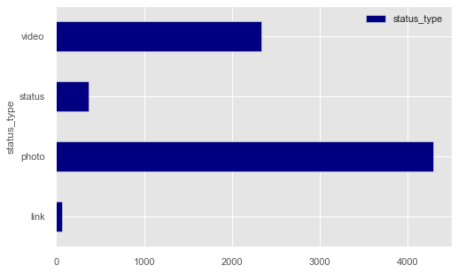

```python
status.plot(kind="barh", color="navy")
```

- Status_type es una variable categórica con los tipos: video, status, photo, y link. Photo y video represetntan el 94% del total de los datos con 4288 y 2334 respectivamente.
- Para poder aplicar los modelos apliaremos LabelEncoder sobre la variable categórica, para convertir las equiquetas en variables numéricas.

```python
from sklearn.preprocessing import LabelEncoder
le=LabelEncoder()
data['status_type']=le.fit_transform(data['status_type'])
data.head(3)
```

|  | status_type | num_reactions | num_comments | num_shares | num_likes | num_loves | num_wows | num_hahas | num_sads | num_angrys |
| --- | --- | --- | --- | --- | --- | --- | --- | --- | --- | --- |
| 0 | 3 | 529 | 512 | 262 | 432 | 92 | 3 | 1 | 1 | 0 |
| 1 | 1 | 150 | 0 | 0 | 150 | 0 | 0 | 0 | 0 | 0 |
| 2 | 3 | 227 | 236 | 57 | 204 | 21 | 1 | 1 | 0 | 0 |

### 1.3 Análisis Gráfico de las variables

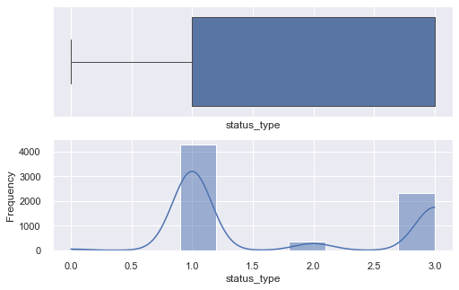

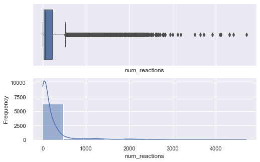

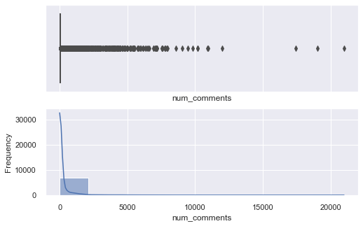

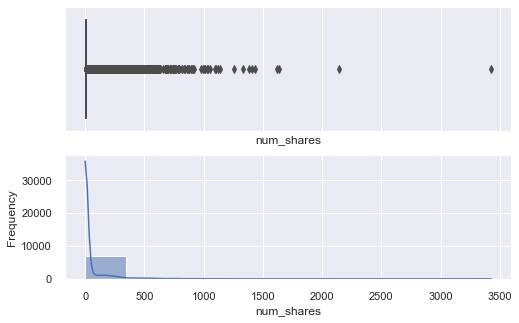

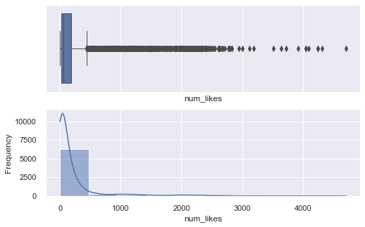

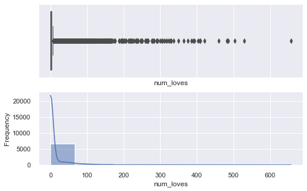

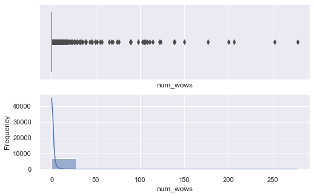

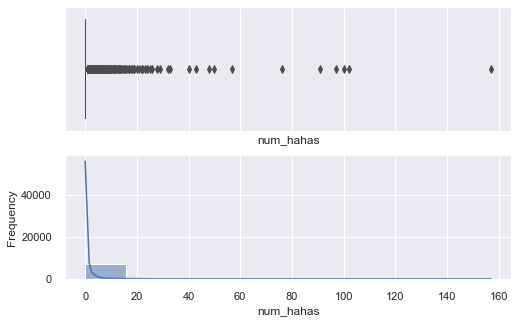

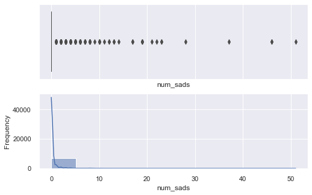

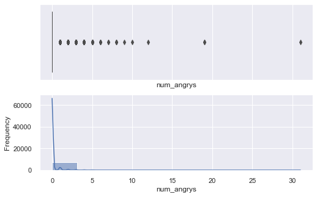

```python
import matplotlib.pyplot as plt
import seaborn as sns

for i in data.columns:
    plt.figure()
    plt.tight_layout()
    sns.set(rc={"figure.figsize":(8, 5)})
    f, (ax_box, ax_hist) = plt.subplots(2, sharex=True)
    plt.gca().set(xlabel= i,ylabel='Frequency')
    sns.boxplot(data[i],  ax=ax_box , linewidth= 1.0)
    sns.histplot(data[i], ax=ax_hist , bins = 10,kde=True)
```

- Como podemos observar, tanto en los gráficos boxplot como en la distribución de Frecuencias, existe una gran dispersión en los datos y la mayoría presentan numerosos outliers, que deberemos tratar en el apartado 2. Preprocesing Data.

### 1.4 Correlación de las variables

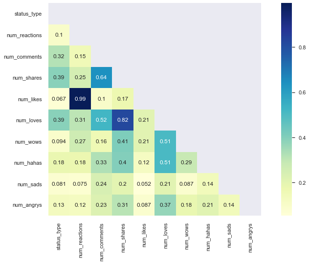

```python
plt.figure(figsize=(15,8))
upp_mat = np.triu(data.corr())
sns.heatmap(data.corr(),cmap="YlGnBu", square = True,annot=True, mask = upp_mat)
```

- Existe una baja correlación en general entre las variables explicativas, salvo en el caso de las variables num_likes y num_reactions, con un coeficiente de correlación de 0,99, y entre num_loves y num_shares con un coeficiente de 0,82.
- También existe una elevada correlación, con doeficientes superiores al 0,5 entre, num_wows y num_loves, num_hahas y num_loves y num_loves y num_comments.
- Aunque aplicaremos en este caso modelos de aprendizaje no supervisado, vamos a evaluar si tener en cuenta o no, la multicolinealidad, afecta al cálculo del PCA (Principal Component Analysis).

### 1.5 Estimación de la multicolinealidad con VIF (Variance Inflation Factor)

Según Hanke, y Wichern (2010)la multicolinealidad es la situación en la cual las variables independientes de una ecuación de regresión múltiple están sumamente intercorrelacionadas. Es decir, existe una relación lineal entre dos o más variables independientes. La multicolinealidad se refiere a que dos o más variables pueden contener información repetida. El impacto que tiene la multicolinealidad en las variables se puede medir mediante un indicador que se conoce como Factor de Inflación de la Varianza o VIF por sus siglas en inglés (variance inflation factor):

- VIF = 1 / (1-R^2)
- Si el valor de VIF es cercano a 1 se puede interpretar que la multicolinealidad no es un gran problema para la variable en cuestión. Un valor de VIF más grande que 1implica que el coeficiente de esa variable puede ser modificado de manera importante conforme se tomen en cuenta a las demás variables en el modelo de regresión.En última instancia,un valor de VIF alto implica que existe información redundante en las variables independientesy que, por lo tanto, cada vez que una de estas variables se modifique,el coeficiente de otra variable puede ser afectado.
- La regla general para decidir sobre la corección de la multicolinealidad es la siguiente:
  1. VIF=1 significa que no existe correlación entre esta variable independiente y cualquier otra.
  2. 1< VIF < 5 sugiere una correlación moderada pero no sería necesario resolverla.
  3. VIF > 5 son niveles críticos de multicolinealidad.

```python
# Shape del dataset original:

data_mc=data
print(data_mc.shape)

# Se divide entre conjunto de variables predictoras y conjunto variables objetivo:

target_label = "status_type"
pred_labels = data_mc.columns.to_list()
pred_labels.remove(target_label)

print(len(pred_labels))

# Conjunto de datos predictor y el conjunto objetivo:

x_pred = data_mc[pred_labels]
y_target = data_mc[target_label]
```

```
(7050, 10)
9
```

```python
# LinearRegression para el calculo de las Ri
from sklearn.linear_model import LinearRegression

def calculateVIF(var_predictoras_df):
    var_pred_labels = list(var_predictoras_df.columns)
    num_var_pred = len(var_pred_labels)

    lr_model = LinearRegression()

    result = pd.DataFrame(index = ['VIF'], columns = var_pred_labels)
    result = result.fillna(0)

    for ite in range(num_var_pred):
        x_features = var_pred_labels[:]
        y_feature = var_pred_labels[ite]
        x_features.remove(y_feature)

        x = var_predictoras_df[x_features]
        y = var_predictoras_df[y_feature]

        lr_model.fit(var_predictoras_df[x_features], var_predictoras_df[y_feature])

        result[y_feature] = 1/(1 - lr_model.score(var_predictoras_df[x_features], var_predictoras_df[y_feature]))

    return result
```

```python
calculateVIF(x_pred.copy(deep = True)).T
```

|  | VIF |
| --- | --- |
| num_reactions | 3.108463e+07 |
| num_comments | 1.792287e+00 |
| num_shares | 3.823288e+00 |
| num_likes | 2.934227e+07 |
| num_loves | 2.322467e+05 |
| num_wows | 1.104074e+04 |
| num_hahas | 2.273337e+03 |
| num_sads | 3.712007e+02 |
| num_angrys | 7.760214e+01 |

- En nuestro caso solo dos variables tienen valores de VIF inferiores a 5, num_comments y num_shares, el resto de variables tienen VIF muy elevados que requieren atención.
- Para eliminar las variables que generan la multicolinealidad aplicaremos una función SelectDataUsingVIF que lo que hace es generar un bucle que termina cuando el valor máximo del VIF es inferior al criterio. En el bucle se elimina la columna de dataframe con el valor de VIF más elevado en cada momento y se vuelve a calcular el VIF de todas las variables.

```python
def selectDataUsingVIF(var_predictoras_df, max_VIF = 5):
    result = var_predictoras_df.copy(deep = True)

    VIF = calculateVIF(result)

    while VIF.values.max() > max_VIF:
        col_max = np.where(VIF == VIF.values.max())[1][0]
        features = list(result.columns)
        features.remove(features[col_max])
        result = result[features]

        VIF = calculateVIF(result)

    return result
```

```python
calculateVIF(selectDataUsingVIF(x_pred)).T
```

|  | VIF |
| --- | --- |
| num_comments | 1.792220 |
| num_shares | 3.804506 |
| num_likes | 1.061638 |
| num_loves | 3.970589 |
| num_wows | 1.403558 |
| num_hahas | 1.371272 |
| num_sads | 1.076220 |
| num_angrys | 1.167430 |

- Al final de proceso se obsera que ha sido eliminada la variable num_reactions y el nuevo valor VIF para el resto de las variables es en todos los casos <5.

### 1.6 Preprocesing Data

### 1.6.1 Evaluación de la normalidad de las variables

```python
data.isnull().values.any()
```

```
False
```

```python
# create a function that checks if the distribution is normal:
def check_normal_distribution(data):

    for i in data[features]:
        stat, p_value_norm = shapiro(data[i])
        print(f'Results for {i}:')
        print('stat=%.3f, p=%.3f' % (stat, p_value_norm))

        if p_value_norm < 0.05 :
            print("Reject null hypothesis at 95% Significance Level  >> The data is not normally distributed")
            print('----------------------------------------------------------------------------------------------')
        else:
            print("Fail to reject null hypothesis at 95€ Significance Level  >> The data is normally distributed")
            print('----------------------------------------------------------------------------------------------')
```

```python
features =["status_type","num_reactions","num_comments","num_shares","num_likes","num_loves","num_wows","num_hahas","num_sads","num_angrys"]
check_normal_distribution(data[features])
```

```
Results for status_type:
stat=0.665, p=0.000
Reject null hypothesis at 95% Significance Level  >> The data is not normally distributed
----------------------------------------------------------------------------------------------
Results for num_reactions:
stat=0.510, p=0.000
Reject null hypothesis at 95% Significance Level  >> The data is not normally distributed
----------------------------------------------------------------------------------------------
Results for num_comments:
stat=0.261, p=0.000
Reject null hypothesis at 95% Significance Level  >> The data is not normally distributed
----------------------------------------------------------------------------------------------
Results for num_shares:
stat=0.337, p=0.000
Reject null hypothesis at 95% Significance Level  >> The data is not normally distributed
----------------------------------------------------------------------------------------------
Results for num_likes:
stat=0.489, p=0.000
Reject null hypothesis at 95% Significance Level  >> The data is not normally distributed
----------------------------------------------------------------------------------------------
Results for num_loves:
stat=0.353, p=0.000
Reject null hypothesis at 95% Significance Level  >> The data is not normally distributed
----------------------------------------------------------------------------------------------
Results for num_wows:
stat=0.110, p=0.000
Reject null hypothesis at 95% Significance Level  >> The data is not normally distributed
----------------------------------------------------------------------------------------------
Results for num_hahas:
stat=0.148, p=0.000
Reject null hypothesis at 95% Significance Level  >> The data is not normally distributed
----------------------------------------------------------------------------------------------
Results for num_sads:
stat=0.130, p=0.000
Reject null hypothesis at 95% Significance Level  >> The data is not normally distributed
----------------------------------------------------------------------------------------------
Results for num_angrys:
stat=0.135, p=0.000
Reject null hypothesis at 95% Significance Level  >> The data is not normally distributed
----------------------------------------------------------------------------------------------
```

- Ninguna de las variables explicativas sigue una función normal y además tienen numerosos outlaers por lo que aplicaremos RobustScales en el procesamiento de datos.

### 1.6.2 RobustScaler

RobustScaler aplica un escalado a las características de forma que sea más robusto a los outliers. Concretamente elimina la mediana y escala los datos de acuerdo a un rango de cuartiles (por defecto el rango intercuantil: el rango de valores entre el 1er cuartil y el 3er cuartil).

Razones para utilizar pruebas robustas:

- Son estables respecto a pequeñas desviaciones del modelo paramétrico asumido (normalidad y homocedasticidad).
- A diferencia de los procedimientos no paramétricos, los procedimientos estadísticos robustos no tratan de comportarse necesariamente bien para una amplia clase de modelos, pero son de alguna manera óptimos en un entorno de cierta distribución de probabilidad, por ejemplo, normal.
- Solucionan los problemas de influencia de los outliers.
- Son más potentes que las pruebas paramétricas y no paramétricas cuando los datos no son normales y/o no son homocedásticos.

```python
from sklearn.preprocessing import RobustScaler
robScaColumns = ["num_reactions","num_comments","num_shares","num_likes","num_loves","num_wows","num_hahas","num_sads","num_angrys"]
scalerRob = preprocessing.RobustScaler().fit(data[robScaColumns])# RobustEscaler
data[robScaColumns] = scalerRob.transform(data[robScaColumns])
```

```python
data.describe().T
```

|  | count | mean | std | min | 25% | 50% | 75% | max |
| --- | --- | --- | --- | --- | --- | --- | --- | --- |
| status_type | 7050.0 | 1.704965 | 0.942399 | 0.000000 | 1.000000 | 1.0 | 3.000000 | 3.000000 |
| num_reactions | 7050.0 | 0.844639 | 2.290224 | -0.294554 | -0.210396 | 0.0 | 0.789604 | 23.022277 |
| num_comments | 7050.0 | 9.580697 | 38.679862 | -0.173913 | -0.173913 | 0.0 | 0.826087 | 912.434783 |
| num_shares | 7050.0 | 10.005638 | 32.899991 | 0.000000 | 0.000000 | 0.0 | 1.000000 | 856.000000 |
| num_likes | 7050.0 | 0.936174 | 2.679418 | -0.345753 | -0.244411 | 0.0 | 0.755589 | 27.731744 |
| num_loves | 7050.0 | 4.242884 | 13.324310 | 0.000000 | 0.000000 | 0.0 | 1.000000 | 219.000000 |
| num_wows | 7050.0 | 1.289362 | 8.719650 | 0.000000 | 0.000000 | 0.0 | 0.000000 | 278.000000 |
| num_hahas | 7050.0 | 0.696454 | 3.957183 | 0.000000 | 0.000000 | 0.0 | 0.000000 | 157.000000 |
| num_sads | 7050.0 | 0.243688 | 1.597156 | 0.000000 | 0.000000 | 0.0 | 0.000000 | 51.000000 |
| num_angrys | 7050.0 | 0.113191 | 0.726812 | 0.000000 | 0.000000 | 0.0 | 0.000000 | 31.000000 |

### 1.6.3 Análisis Gráfico de las variables con RobustScaler

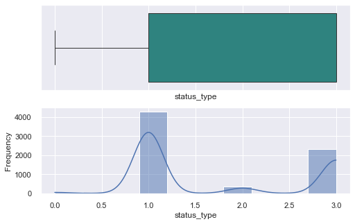

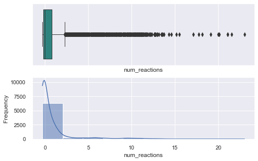

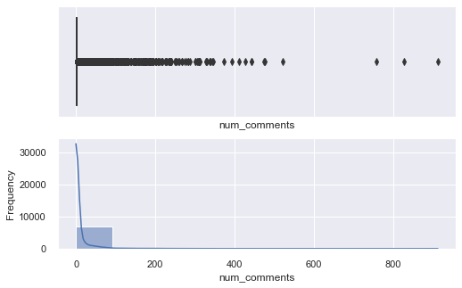

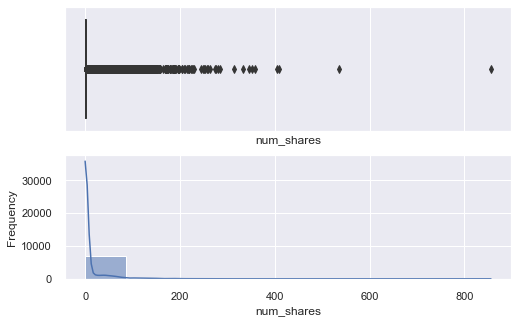

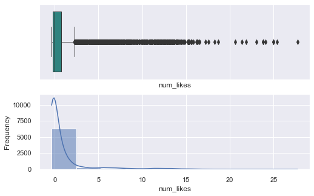

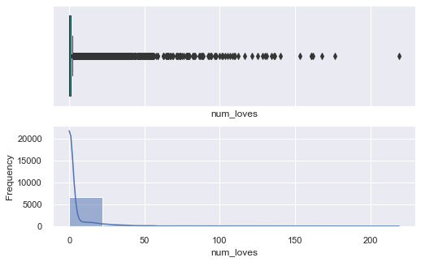

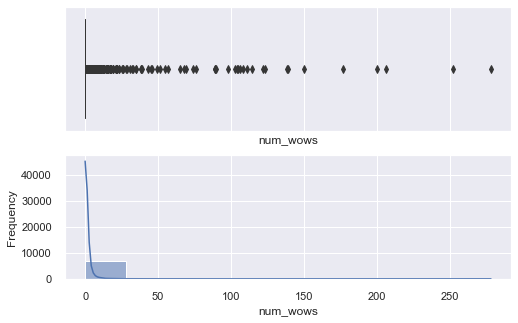

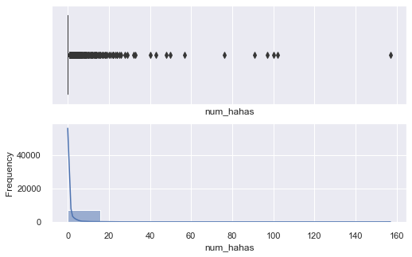

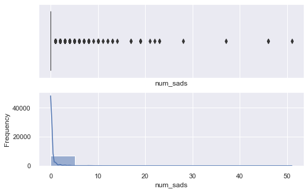

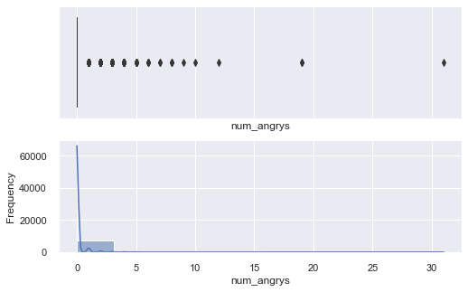

```python
for i in data.columns:
    plt.figure()
    plt.tight_layout()
    sns.set(rc={"figure.figsize":(8, 5)})
    f, (ax_box, ax_hist) = plt.subplots(2, sharex=True)
    plt.gca().set(xlabel= i,ylabel='Frequency')
    sns.boxplot(data[i],  ax=ax_box , linewidth= 1.0, palette="viridis")
    sns.histplot(data[i], ax=ax_hist , bins = 10,kde=True, palette="viridis")
```

- Después de aplicar RobustScaler hemos reducido la escla de la dispersión de las variables, pero no hemos solucionado de forma efectiva los outliers, y esto puede distosionar los resultados de la aplicación de los modelos de aprendizaje no supervisado, como es el caso de KMeans, que no se comporta bien cuando las variables presentan tantos outliers.

### 1.7 PCA (Principal Component Analysis)

### 1.7.1 PCA con todas las variables

```python
from sklearn.decomposition import PCA

X = data.drop(['status_type'],axis=1)
y = data['status_type']
```

```python
X.head()
```

|  | num_reactions | num_comments | num_shares | num_likes | num_loves | num_wows | num_hahas | num_sads | num_angrys |
| --- | --- | --- | --- | --- | --- | --- | --- | --- | --- |
| 0 | 2.324257 | 22.086957 | 65.50 | 2.229508 | 30.666667 | 3.0 | 1.0 | 1.0 | 0.0 |
| 1 | 0.448020 | -0.173913 | 0.00 | 0.548435 | 0.000000 | 0.0 | 0.0 | 0.0 | 0.0 |
| 2 | 0.829208 | 10.086957 | 14.25 | 0.870343 | 7.000000 | 1.0 | 1.0 | 0.0 | 0.0 |
| 3 | 0.254950 | -0.173913 | 0.00 | 0.315946 | 0.000000 | 0.0 | 0.0 | 0.0 | 0.0 |
| 4 | 0.759901 | -0.173913 | 0.00 | 0.870343 | 3.000000 | 0.0 | 0.0 | 0.0 | 0.0 |

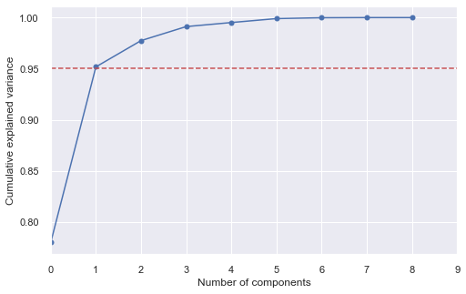

```python
pca = PCA().fit(X)
plt.plot(np.cumsum(pca.explained_variance_ratio_), marker = "o")
plt.axhline(0.95, color = "r", linestyle = "--")
plt.xlim([0, 9])
plt.xlabel('Number of components')
plt.ylabel('Cumulative explained variance')
```

```python
pca = PCA(n_components=1)
pca.fit(X)
df_pca = pd.DataFrame(pca.transform(X), columns=['pca1'], index=data.index)
df_pca.head()
```

|  | pca1 |
| --- | --- |
| 0 | 49.098473 |
| 1 | -14.527011 |
| 2 | 3.545756 |
| 3 | -14.531109 |
| 4 | -13.895270 |

### 1.7.2 PCA sin Multicolinealidad

```python
X_sinMcl = data.drop(['status_type','num_reactions'],axis=1)
y_sinMcl = data['status_type']
```

```python
X_sinMcl.head()
```

|  | num_comments | num_shares | num_likes | num_loves | num_wows | num_hahas | num_sads | num_angrys |
| --- | --- | --- | --- | --- | --- | --- | --- | --- |
| 0 | 22.086957 | 65.50 | 2.229508 | 30.666667 | 3.0 | 1.0 | 1.0 | 0.0 |
| 1 | -0.173913 | 0.00 | 0.548435 | 0.000000 | 0.0 | 0.0 | 0.0 | 0.0 |
| 2 | 10.086957 | 14.25 | 0.870343 | 7.000000 | 1.0 | 1.0 | 0.0 | 0.0 |
| 3 | -0.173913 | 0.00 | 0.315946 | 0.000000 | 0.0 | 0.0 | 0.0 | 0.0 |
| 4 | -0.173913 | 0.00 | 0.870343 | 3.000000 | 0.0 | 0.0 | 0.0 | 0.0 |

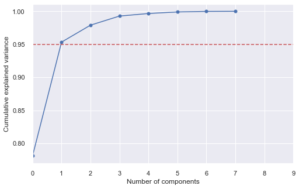

```python
pca = PCA().fit(X_sinMcl)
plt.plot(np.cumsum(pca.explained_variance_ratio_), marker = "o")
plt.axhline(0.95, color = "r", linestyle = "--")
plt.xlim([0, 9])
plt.xlabel('Number of components')
plt.ylabel('Cumulative explained variance')
```

```python
pca_sin = PCA(n_components=1)
pca_sin.fit(X_sinMcl)
df_pca_sin = pd.DataFrame(pca_sin.transform(X_sinMcl), columns=['pca1'], index=data.index)
df_pca_sin.head()
```

|  | pca1 |
| --- | --- |
| 0 | 49.083497 |
| 1 | -14.523455 |
| 2 | 3.545969 |
| 3 | -14.525461 |
| 4 | -13.895130 |

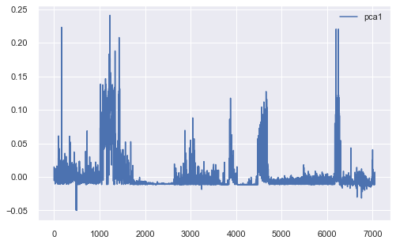

```python
diferencias=df_pca-df_pca_sin
diferencias.plot()
```

- Como se observa en el gráfico, las diferencias en los valores en el PCA calculado sobre el total de variables y eliminando la variable que genera la multicolinealidad nos superan en ningun momento el rango de (-0.05, 0,25), por lo que utilizaremos el Data Frame completo.

### 1.8 Modelos

### 1.8.1 K-means

El algoritmo K-means (MacQueen, 1967) agrupa las observaciones en un número predefinido de K clusters de forma que, la suma de las varianzas internas de los clusters, sea lo menor posible. El algoritmo empleado sigue el siguiente proceso:

- Especificar el número K de clusters que se quieren crear.
- Seleccionar de forma aleatoria k observaciones del set de datos como centroides iniciales.
- Asignar cada una de las observaciones al centroide más cercano.
- Para cada uno de los K clusters generados en el paso 3, recalcular su centroide.
- Repetir los pasos 3 y 4 hasta que las asignaciones no cambien o se alcance el número máximo de iteraciones establecido.

Este algoritmo garantiza que, en cada paso, se reduzca la intra-varianza total de los clusters hasta alcanzar un óptimo local. Debido a que el algoritmo de K-means no evalúa todas las posibles distribuciones de las observaciones sino solo parte de ellas, los resultados obtenidos dependen de la asignación aleatoria inicial (paso 2). Por esta razón, es importante ejecutar el algoritmo varias veces (25-50), cada una con una asignación aleatoria inicial distinta, y seleccionar aquella que haya conseguido una menor varianza total.

##### Ventajas y desventajas

- K-means es uno de los métodos de clustering más utilizados. Destaca por la sencillez y velocidad de su algoritmo, sin embargo, presenta una serie de limitaciones que se deben tener en cuenta.
- Requiere que se indique de antemano el número de clusters que se van a crear. Esto puede ser complicado si no se dispone de información adicional sobre los datos con los que se trabaja. Se han desarrollado varias estrategias para ayudar a identificar potenciales valores óptimos de K (elbow, shilouette), pero todas ellas son orientativas.
- Dificultad para detectar clusters alargados o con formas irregulares.
- Las agrupaciones resultantes pueden variar dependiendo de la asignación aleatoria inicial de los centroides. Para minimizar este problema, se recomienda repetir el proceso de clustering entre 25-50 veces y seleccionar como resultado definitivo el que tenga menor suma total de varianza interna. Aun así, solo se puede garantizar la reproducibilidad de los resultados si se emplean semillas.
- Presenta problemas de robustez frente a outliers. La única solución es excluirlos o recurrir a otros métodos de clustering más robustos como K-medoids (PAM).

### 1.8.1 a) Número óptimo de Clusters con el Método Elbow

- El método Elbow, también conocido como método del codo, sigue una estrategia de probar un rango de valores del hiperparámetro en cuestión, representar gráficamente los resultados obtenidos con cada uno, e identificar aquel punto de la curva (codo) a partir del cual la mejora deja de ser notable.
- En los casos de partitioning clustering, como por ejemplo K-means, las observaciones se agrupan de una forma tal que se minimiza la varianza total intra-cluster.
- El método Elbow calcula la varianza total intra-cluster en función del número de clusters y escoge como óptimo aquel valor a partir del cual añadir más clusters apenas consigue mejoría.

```python
from sklearn.cluster import KMeans
from kneed import KneeLocator

def elbow_plot(data):
    """Create elbow plot from normalized data"""
    sse = {}
    sse_r = []
    for k in range(1, 21):
        kmeans = KMeans(n_clusters=k, random_state=1)
        kmeans.fit(data)
        sse[k] = kmeans.inertia_
        sse_r.append(kmeans.inertia_)

    plt.title('Elbow plot for K selection')
    plt.xlabel('k')
    plt.ylabel('SSE')
    sns.pointplot(x=list(sse.keys()),
                 y=list(sse.values()))
    plt.show()
    return sse_r
```

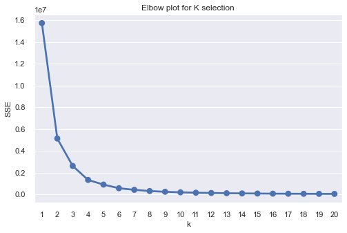

```python
sse = elbow_plot(df_pca) #Se ejecuta con PCA
```

```python
kl = KneeLocator(range(1, 21), sse, curve="convex", direction="decreasing")
kl.elbow
```

```
4
```

### 1.8.1 b) KMeans Clusters

```python
k_means = KMeans(n_clusters=4, random_state=1)
k_means.fit(X)
```

```
KMeans(n_clusters=4, random_state=1)
```

```python
y_pred = k_means.predict(X)
y_pred
```

```
array([2, 0, 0, ..., 0, 0, 0])
```

```python
data['Cluster'] = y_pred
data.head()
```

|  | status_type | num_reactions | num_comments | num_shares | num_likes | num_loves | num_wows | num_hahas | num_sads | num_angrys | Cluster |
| --- | --- | --- | --- | --- | --- | --- | --- | --- | --- | --- | --- |
| 0 | 3 | 2.324257 | 22.086957 | 65.50 | 2.229508 | 30.666667 | 3.0 | 1.0 | 1.0 | 0.0 | 2 |
| 1 | 1 | 0.448020 | -0.173913 | 0.00 | 0.548435 | 0.000000 | 0.0 | 0.0 | 0.0 | 0.0 | 0 |
| 2 | 3 | 0.829208 | 10.086957 | 14.25 | 0.870343 | 7.000000 | 1.0 | 1.0 | 0.0 | 0.0 | 0 |
| 3 | 1 | 0.254950 | -0.173913 | 0.00 | 0.315946 | 0.000000 | 0.0 | 0.0 | 0.0 | 0.0 | 0 |
| 4 | 1 | 0.759901 | -0.173913 | 0.00 | 0.870343 | 3.000000 | 0.0 | 0.0 | 0.0 | 0.0 | 0 |

```python
df_pca["Cluster"] = k_means.labels_
```

```python
df_pca.Cluster.value_counts()
```

```
0    6208
2     601
1     207
3      34
Name: Cluster, dtype: int64
```

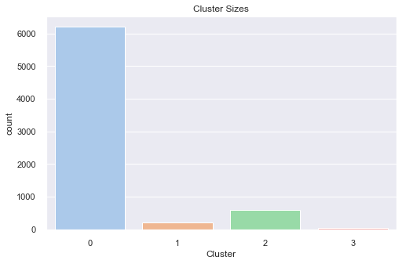

```python
sns.countplot(x = df_pca.Cluster, palette ="pastel").set(
    title = "Cluster Sizes")
plt.show()
```

- La distribución de los valores del Data Frame entre los diferentes clusters no es homogénea, y el cluster 0 acumula el 88,05% de los valores.

### 1.8.1 c) Visualizacíón Clusters en función de las variables

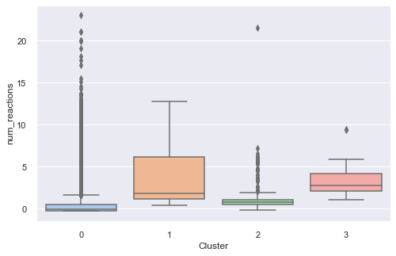

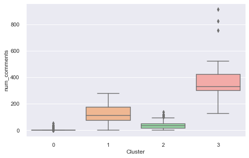

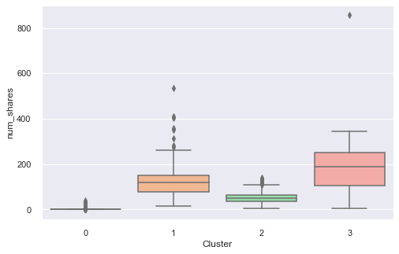

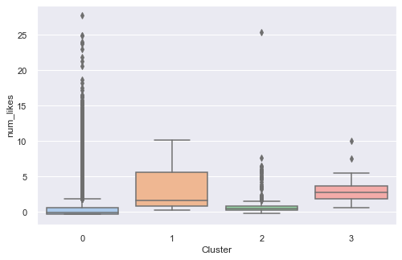

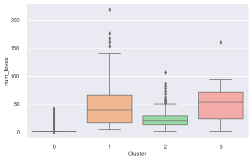

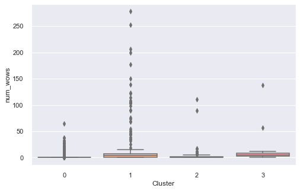

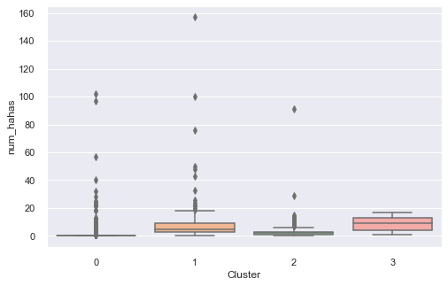

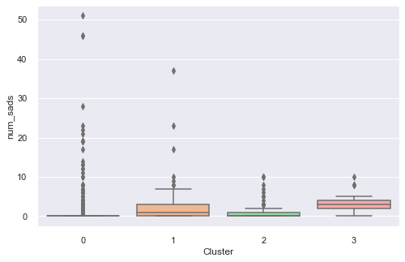

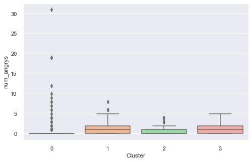

```python
columns = data.columns[1:10]

for i in columns:
    plt.figure()
    sns.set(rc={"figure.figsize":(8, 5)})
    sns.boxplot(x='Cluster', y=i, data=data, palette="pastel")
```

- De las gráficas de boxplot de las diferentes variables podemos observar que las primeras: num_reactions, num_comments, num_shares, num_loves y num_likes tienen valores de mediana y de desviación estándar bastante diferntes entre los distintos clusters; el resto de variaales sin embargo no presentan grandes diferencias en la distribución de los cuartiles.
- Otro factor destacable es la existencia de numerosos outliers en el clúster 0 y 1, en la mayoría de las variables, lo que probablemente está distorsionando la clasificación de los valores en los diferentes clústers.

[figure not shown]

```python
ax = sns.countplot(x="Cluster", hue="status_type", data=data, palette="pastel")
#place legend in upper left of plot
plt.legend(loc='upper right', title="status_type")
```

- El cluster 0 concentra el mayor número de datos de la variable status_type, en sus cuatro categorías: link, photo, status y video.
- El cluster 1 solo tiene datos de videos y los cluster 2 y 3 tienen datos del tipo photo, status y video.

### 1.8.1 d) Visualización de datos los Clusters por pares de variables

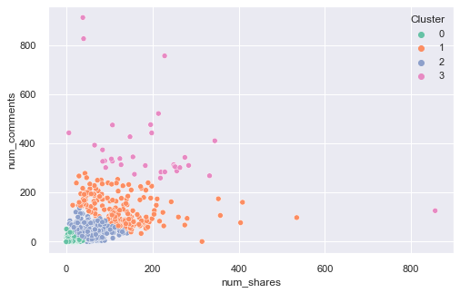

```python
sns.scatterplot(x = 'num_shares', y = 'num_comments',hue='Cluster',data =data,legend='full',palette="Set2")
```

- Los clusters 0,1 y 2 aparecen definidos entre los valores de las variables num_comments y num_shares, el cluster 3 si bien está diferenciado del resto, tiene una mayor dispersión de valores.

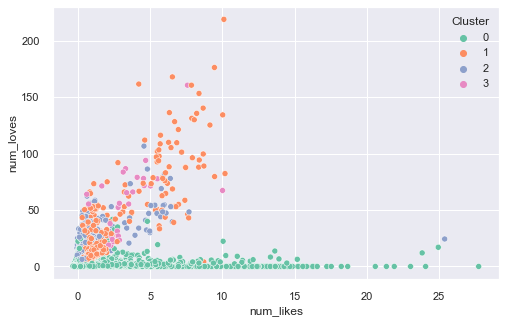

```python
sns.scatterplot(x = 'num_likes', y = 'num_loves',hue='Cluster',data =data,legend='full',palette="Set2")
```

- Entre las variables num_loves y num_likes también aparecen definidos los clusters 0 y 1, pero los clusters 2 y 3 se intercalan en el area de otros clusters.

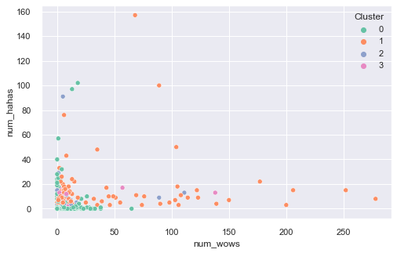

```python
sns.scatterplot(x = 'num_wows', y = 'num_hahas',hue='Cluster',data =data,legend='full',palette="Set2")
```

- En el gráfico de las variables num_hahas y num_wows no se aprecia una diferencia significativa entre las posiciones de los diferentes Clusters

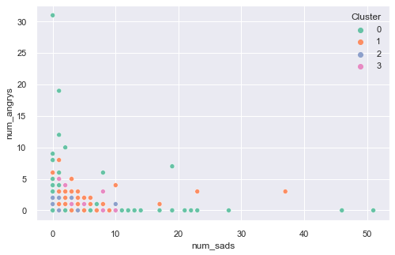

```python
sns.scatterplot(x = 'num_sads', y = 'num_angrys',hue='Cluster',data =data,legend='full',palette="Set2")
```

- Igual que en caso anterior, no hay diferencias en la distribución de los valores de los clusters para estas variables, num_angrys y num_sads, y se debe al menor número de datos de las mismas informados en el data frame, por lo que su influencia en la clasificación de los cluster es menor.

### 1.8.2 K-medoids

K-medoids es un método de clustering muy similar a K-means en cuanto a que ambos agrupan las observaciones en K clusters, donde K es un valor preestablecido por el analista. La diferencia es que, en K-medoids, cada cluster está representado por una observación presente en el cluster (medoid), mientras que en K-means cada cluster está representado por su centroide, que se corresponde con el promedio de todas las observaciones del cluster, pero con ninguna en particular.

Una definición más exacta del término medoid es: elemento dentro de un cluster cuya distancia promedio entre él y todos los demás elementos del mismo cluster es lo menor posible. Se corresponde con el elemento más central del cluster y por lo tanto puede considerarse como el más representativo. El hecho de utilizar "medoids" en lugar de centroides hace de K-medoids un método más robusto que K-means, viéndose menos afectado por outliers o ruido.

```python
from sklearn_extra.cluster import KMedoids
kmedoids = KMedoids(n_clusters=4, random_state=1).fit(X)
kmedoids.labels_
```

```
array([1, 2, 3, ..., 0, 2, 0], dtype=int64)
```

```python
kmedoids.cluster_centers_
```

```
array([[-0.21039604, -0.13043478,  0.        , -0.24441133,  0.        ,
         0.        ,  0.        ,  0.        ,  0.        ],
       [ 1.16584158, 46.17391304, 63.5       ,  0.91803279, 26.33333333,
         0.        ,  3.        ,  0.        ,  1.        ],
       [ 0.63118812,  0.26086957,  0.5       ,  0.75707899,  0.66666667,
         0.        ,  0.        ,  0.        ,  0.        ],
       [ 2.85891089,  2.60869565,  2.        ,  3.39195231,  2.66666667,
         2.        ,  0.        ,  0.        ,  0.        ]])
```

```python
df2_pca=df_pca.drop("Cluster",axis=1)
df2_pca["Cluster"] = kmedoids.labels_
df2_pca.head()
```

|  | pca1 | Cluster |
| --- | --- | --- |
| 0 | 49.098473 | 1 |
| 1 | -14.527011 | 2 |
| 2 | 3.545756 | 3 |
| 3 | -14.531109 | 0 |
| 4 | -13.895270 | 2 |

### 1.8.2 a) KMedoids Clusters

```python
df2_pca.Cluster.value_counts()
```

```
0    3896
2    1308
3    1109
1     737
Name: Cluster, dtype: int64
```

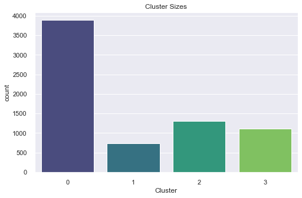

```python
sns.countplot(x = df2_pca.Cluster, palette ="viridis").set(title = "Cluster Sizes")
plt.show()
```

- La distribución de los Cluster en este csso es un poco más homogénea entre el 1,2 y 3, pero el cluster 0 sigue acumulando el 55,26% de los datos

```python
data = data.drop("Cluster", axis=1)
data['Cluster'] = kmedoids.labels_
data.head()
```

|  | status_type | num_reactions | num_comments | num_shares | num_likes | num_loves | num_wows | num_hahas | num_sads | num_angrys | Cluster |
| --- | --- | --- | --- | --- | --- | --- | --- | --- | --- | --- | --- |
| 0 | 3 | 2.324257 | 22.086957 | 65.50 | 2.229508 | 30.666667 | 3.0 | 1.0 | 1.0 | 0.0 | 1 |
| 1 | 1 | 0.448020 | -0.173913 | 0.00 | 0.548435 | 0.000000 | 0.0 | 0.0 | 0.0 | 0.0 | 2 |
| 2 | 3 | 0.829208 | 10.086957 | 14.25 | 0.870343 | 7.000000 | 1.0 | 1.0 | 0.0 | 0.0 | 3 |
| 3 | 1 | 0.254950 | -0.173913 | 0.00 | 0.315946 | 0.000000 | 0.0 | 0.0 | 0.0 | 0.0 | 0 |
| 4 | 1 | 0.759901 | -0.173913 | 0.00 | 0.870343 | 3.000000 | 0.0 | 0.0 | 0.0 | 0.0 | 2 |

```python
data.Cluster.value_counts() # comprobación de la asignación de cluster en el Data Frame
```

```
0    3896
2    1308
3    1109
1     737
Name: Cluster, dtype: int64
```

### 1.8.2 b) Visualizacíón Clusters en función de las variables

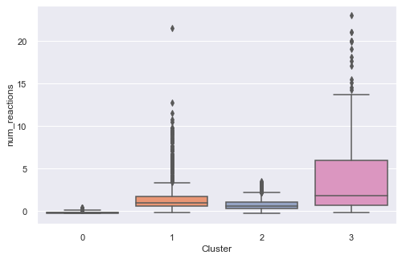

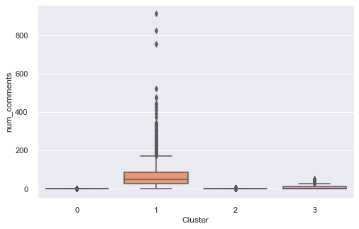

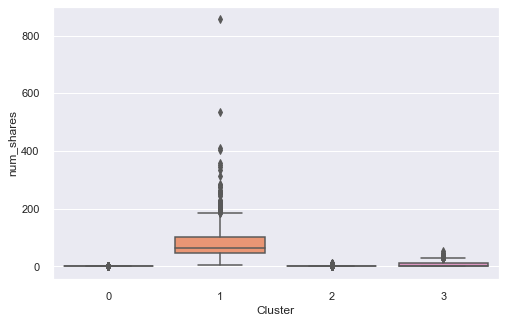

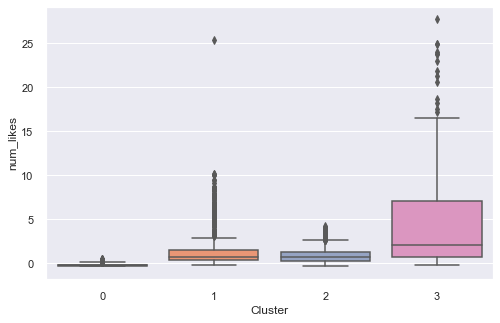

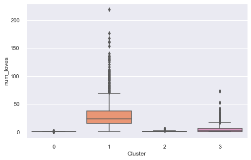

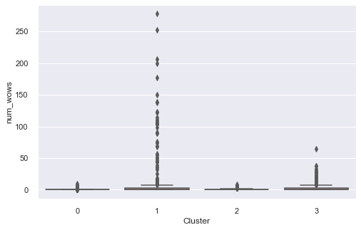

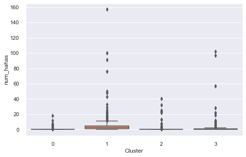

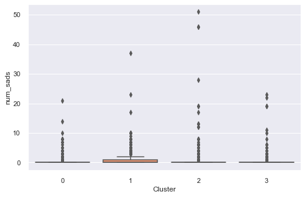

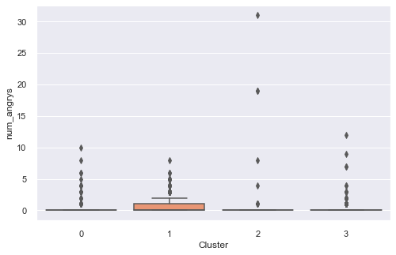

```python
columns = data.columns[1:10]

for i in columns:
    plt.figure()
    sns.set(rc={"figure.figsize":(8, 5)})
    sns.boxplot(x='Cluster', y=i, data=data, palette="Set2")
```

- Como en el modelo anterior, existen variables en las cuales las gráficas boxplot son significativamente diferentes entre clusters, pero siguen produciéndose sistorsiones derivadas de numerosos outliers.

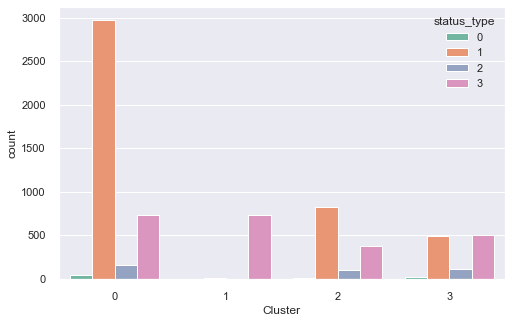

```python
ax = sns.countplot(x="Cluster", hue="status_type", data=data, palette="Set2")
#place legend in upper left of plot
plt.legend(loc='upper right', title="status_type")
```

- Como en el modelo anterior, el cluster 0 es el que tiene valores de status_type de sus cuatro tipos: like, photo, status y video.
- Con este nuevo modelo, también los clusters 2 y 3 cuentan con un mayor número de elementos del tipo: photo, status y vídeo.
- Tambíen el cluster 1 tiene asignados más elementos del tipo video de la variable status_type.

### Exercici 2

#### Classifica els diferents registres utilitzant l'algorisme de clustering jeràrquic.

### 2.1 Selección de una muestra del DataFrame

```python
df_sample = data.sample(frac = 0.5, random_state = 0)
```

```python
from sklearn.decomposition import PCA

X_sample = df_sample.drop(['status_type'],axis=1)
y_sample = df_sample['status_type']
```

```python
X_sample.shape
```

```
(3525, 10)
```

### 2.2 PCA (Principal Components Analysis)

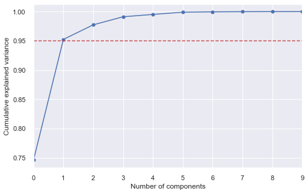

```python
pca = PCA().fit(X_sample)
plt.plot(np.cumsum(pca.explained_variance_ratio_), marker = "o")
plt.axhline(0.95, color = "r", linestyle = "--")
plt.xlim([0, 9])
plt.xlabel('Number of components')
plt.ylabel('Cumulative explained variance')
```

```python
pca = PCA(n_components=1)
pca.fit(X_sample)
df_pca_agg = pd.DataFrame(pca.transform(X_sample), columns=['pca1'], index=df_sample.index) #'pca2','pca3','pca4'
df_pca_agg.head()
```

|  | pca1 |
| --- | --- |
| 4412 | -15.108972 |
| 4565 | 236.610688 |
| 5660 | -15.074925 |
| 2724 | -15.037243 |
| 6649 | -14.362794 |

```python
df_pca_agg.shape
```

[output not shown]

### 2.3 Dendrograma

Un dendrograma es un diagrama en forma de árbol que se utiliza para visualizar la relación entre grupos. Cuanto mayor sea la distancia de las líneas verticales en el dendrograma, mayor será la distancia entre esos grupos. La clave para interpretar un dendrograma es concentrarse en la altura a la que se unen dos objetos.

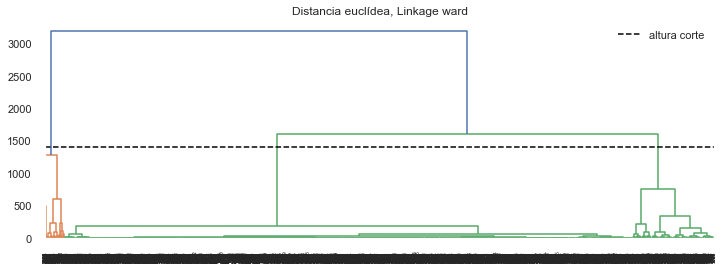

```python
import scipy.cluster.hierarchy as shc

fig, ax = plt.subplots(1, 1, figsize=(12, 4))
altura_corte = 1400
shc.dendrogram(shc.linkage(df_pca_agg, method = "ward"), ax=ax)
ax.set_title("Distancia euclídea, Linkage ward")
ax.axhline(y=altura_corte, c = 'black', linestyle='--', label='altura corte')
ax.legend();
```

- Hemos seleccionado tres clusters, si bien podrían ser dos si seguimos la clasificación por colores, pero dada la tendencia a concentrar los datos en el cluster 0, suponemos que 3 clusters aportarán mas información a la clasificación, si bien no tienen porqué ser el número óptimo de clusters.

### 2.4 AgglomerativeClustering Model

```python
from sklearn.cluster import AgglomerativeClustering
agglo = AgglomerativeClustering(n_clusters = 3, affinity = "euclidean", linkage = "ward")
y_pred_agg= agglo.fit_predict(df_pca_agg)
y_pred_agg
```

```
array([2, 0, 2, ..., 2, 2, 2], dtype=int64)
```

```python
df_sample['Cluster'] = y_pred_agg
df_sample.head()
```

|  | status_type | num_reactions | num_comments | num_shares | num_likes | num_loves | num_wows | num_hahas | num_sads | num_angrys | Cluster |
| --- | --- | --- | --- | --- | --- | --- | --- | --- | --- | --- | --- |
| 4412 | 3 | -0.289604 | -0.173913 | 0.00 | -0.339791 | 0.000000 | 0.0 | 0.0 | 0.0 | 0.0 | 2 |
| 4565 | 3 | 10.779703 | 111.608696 | 203.75 | 9.138599 | 125.333333 | 252.0 | 15.0 | 1.0 | 2.0 | 0 |
| 5660 | 1 | -0.254950 | -0.130435 | 0.00 | -0.298063 | 0.000000 | 0.0 | 0.0 | 0.0 | 0.0 | 2 |
| 2724 | 1 | -0.254950 | -0.173913 | 0.00 | -0.304024 | 0.333333 | 0.0 | 0.0 | 0.0 | 0.0 | 2 |
| 6649 | 1 | -0.012376 | 0.260870 | 0.25 | -0.029806 | 0.000000 | 4.0 | 0.0 | 0.0 | 0.0 | 2 |

```python
df_pca_agg["Cluster"] = agglo.labels_
```

```python
df_pca_agg.head()
```

|  | pca1 | Cluster |
| --- | --- | --- |
| 4412 | -15.108972 | 2 |
| 4565 | 236.610688 | 0 |
| 5660 | -15.074925 | 2 |
| 2724 | -15.037243 | 2 |
| 6649 | -14.362794 | 2 |

```python
df_pca_agg.Cluster.value_counts()
```

```
2    2991
1     431
0     103
Name: Cluster, dtype: int64
```

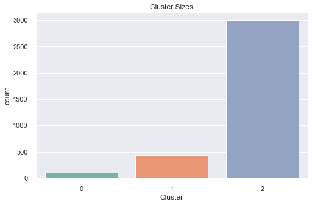

```python
sns.countplot(x = df_pca_agg.Cluster, palette = "Set2").set(title = "Cluster Sizes")
plt.show()
```

- De nuevo la clasificación de valores se concentra en un mismo cluster, pero en este caso se corresponde con el cluster 2, que acumula el 84,85% de los datos.

### 2.5 Visualizacíón Clusters en función de las variables

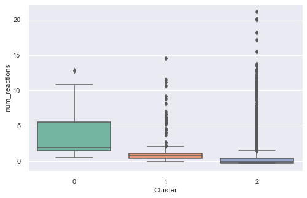

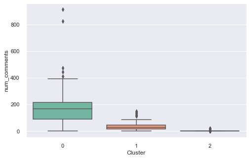

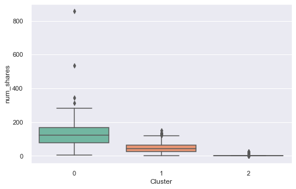

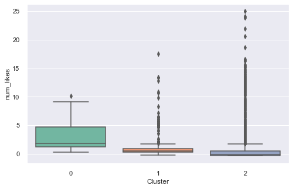

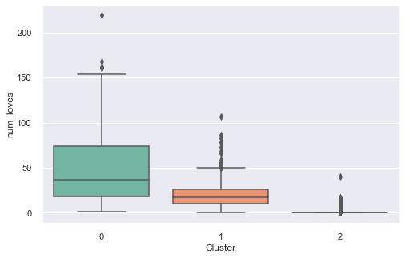

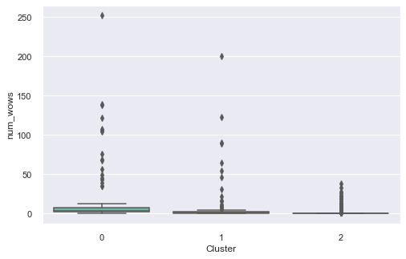

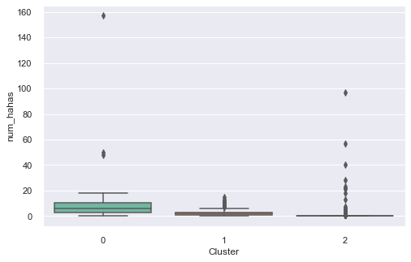

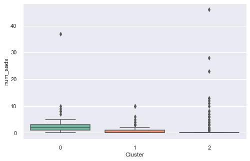

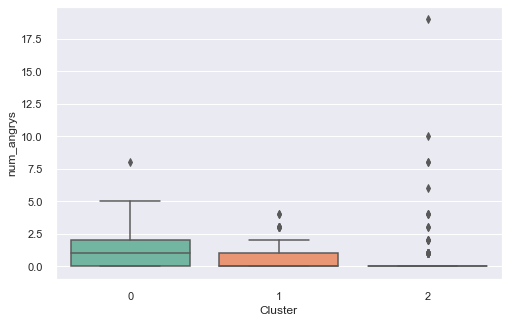

```python
columns = df_sample.columns[1:10]

for i in columns:
    plt.figure()
    sns.set(rc={"figure.figsize":(8, 5)})
    sns.boxplot(x='Cluster', y=i, data=df_sample, palette="Set2")
```

- En general la visualización de los datos de cada variable por cada cluster ofrece una representación más homogénea, aunque siguen apareciendo numerosos ouliers, pero tiene menos efecto en la distribución de los datos en relación a la mediana.
- A difenrencia de las clasificaciones anteriores, los outliers se concentran más en el custer 2, que es el que tiene más datos, de la misma forma que en los modelos anteriores sucedía con el cluster 0.

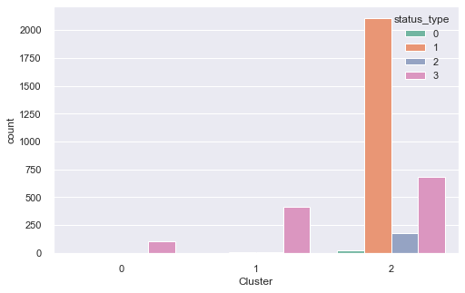

```python
ax = sns.countplot(x="Cluster", hue="status_type", data=df_sample, palette="Set2")
#place legend in upper left of plot
plt.legend(loc='upper right', title="status_type")
```

- En esta clasificación el cluster 2 tiene datos con las cuatro características de la variable status_type: link, photo, status y video, mientras que los clusters 0 y 1 solo tienen datos correspondientes al tipo video.